# Zadanie 2 Bagging

RKiermasz

16 lutego 2019

# Wczytanie danych

Zmienna objaśniana Y, jest dyskretna i wygląda na to, że funkcja ją opisująca jest wykładnicza. Zmienna ta jest ilościowa, więć w dalszych rozważaniach proponuję się budować drzewa klasyfikacyjne oparte na regresji.

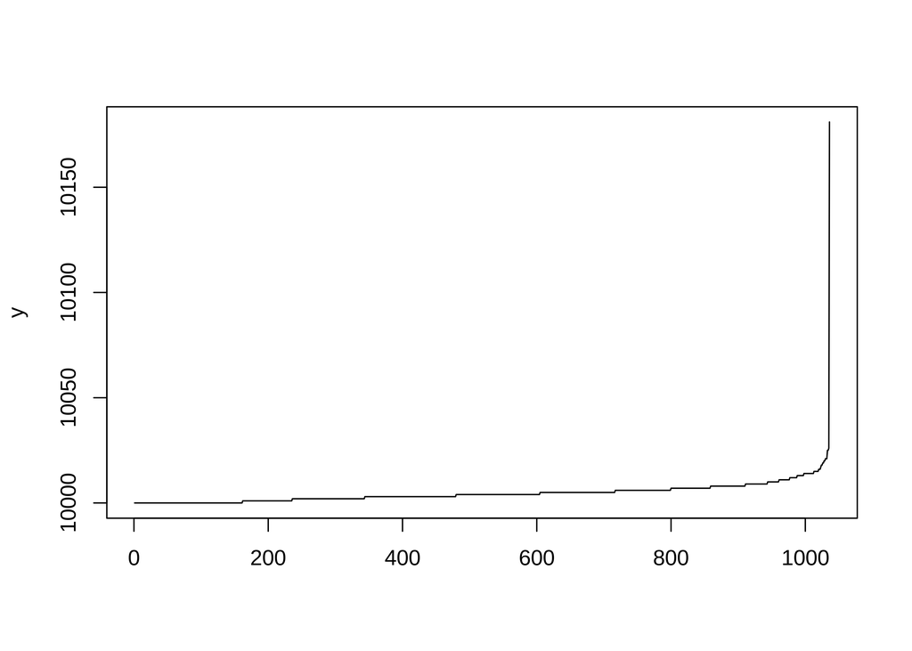

```r
setwd("/home/cengu/Dokumenty/cv/doofert/2/Data Scientist Nazwa firmy 3SOFT/rekrutacjadatascientistzadania/")
descriptive<-read.csv2("descriptive.csv",stringsAsFactors = FALSE)
# time<-read.csv2("time.csv",stringsAsFactors = FALSE)
# time$DATE<-as.Date(time$DATE,format="%Y-%m-%d")
signal<-read.csv2("signal.csv",stringsAsFactors = FALSE)
plot(signal$y[order(signal$y)],xlab="",ylab="y", type="l")
```

```r
library(dplyr)
library(rpart)
library(rpart.plot)
pelneDane<-signal%>%inner_join(descriptive, by=c("id"="id"))
# pelneDane<-signal%>%inner_join(time, by=c("id"="id"))
library(stringr)

dt_pred <- function(dateset, nrows=0.8, ncols=0.8, seedCols=43904, seedRows=43904){
  ktoreKolumny<-"y ~"
  ileKolumn<-(dim(dateset)[2]-2)#minus 1 bo id, minus 1 bo y
  set.seed(seedCols)
  losoweKolumny<-sample(1:ileKolumn,round(ncols*ileKolumn))
  # losoweKolumny<-losoweKolumny[order(losoweKolumny)]#do usuniecia, potrzebne do sprawdzenia wybranych kolumn
  ileWierszy<-(dim(dateset)[1])
  # rm(.Random.seed, envir=globalenv())#wylacza seed
  set.seed(seedRows)
  losoweWiersze<-sample(1:ileWierszy,round(nrows*ileWierszy))
  # losoweWiersze<-losoweWiersze[order(losoweWiersze)]#do usuniecia, potrzebne do sprawdzenia wybranych kolumn
  for(i in 1:length(losoweKolumny)){
    ktoreKolumny<-paste0(ktoreKolumny,paste0(" + x_",losoweKolumny[i]))
  }
  ktoreKolumny<- sub(' \\+', '', ktoreKolumny)
  dateset<-dateset[losoweWiersze,]
  # test<-dateset[-losoweWiersze,]
  fit_tree <- rpart(ktoreKolumny, data=dateset)
  # parametryDrzewa<-list(fit_tree=fit_tree, train=train, test=test)
  return(fit_tree)
}

dt_bagg <- function(dateset, nrows=0.8, ncols=0.8, seedCols=43904, seedRows=43904, ileDrzew=8){
  listaDrzew<-list()
  for(i in 1:ileDrzew){
    parametryDrzewa<-dt_pred(dateset, nrows=nrows, ncols=ncols, seedCols=seedCols+i-1, seedRows=seedRows+i-1)#nie ma sensu budowac takich samych drzew, wiec dodano do seed=seed+i1
    listaDrzew[[i]]<-parametryDrzewa
  }
  return(listaDrzew)
}

sprawdzModel <- function(parametryBaggingu, test, czyPrint=TRUE){
  prognoza<-rep(NA,nrow(test))#stworzenie obiektu za pomoca pierwszej kolumny
  # par(mfrow=c(2,2))
  for(i in 1:length(parametryBaggingu)){
    predict<-predict(parametryBaggingu[[i]],test)
    # plot(test$y-predict)#mozna usunac obserwacje odstajaca
    # title(i)
    prognoza<-cbind(prognoza,predict)
    # rmse<-mean((test$y-predict)^2)^0.5
    # print(paste0("drzewo nr: ",i," rmse :",round(rmse,3)))
  }
  prognoza<-prognoza[,-1]#usuniecie pierwszej kolumny
  prognoza<-apply(prognoza,1,mean)
  rmse<-mean((test$y-prognoza)^2)^0.5
  R2<-sum((prognoza-mean(test$y))^2)/sum((test$y-mean(test$y))^2)
  if(czyPrint==TRUE){
  print(paste0("rmse=",round(rmse,3), ", R^2=",round(R2,3)))}
  # sprawdzenieModelu<- list(rmse,R2)
  # names(sprawdzenieModelu)<-c("rmse","R2")
  sprawdzenieModelu<- c(rmse,R2)
  return(sprawdzenieModelu)
}

pobierzPrognoze <- function(parametryBaggingu, test){
  prognoza<-rep(NA,nrow(test))#stworzenie obiektu za pomoca pierwszej kolumny
  for(i in 1:length(parametryBaggingu)){
    predict<-predict(parametryBaggingu[[i]],test)
    prognoza<-cbind(prognoza,predict)
  }
  prognoza<-prognoza[,-1]#usuniecie pierwszej kolumny
  prognoza<-apply(prognoza,1,mean)
  return(prognoza)
}
```

# Zbudownie modeli

1. 100 niezależnych drzew, gdzie każde indywidualne drzewo uczone będzie na 80% obserwacji ze zbioru treningowego oraz 80% dostępnych kolumn
2. 200 niezależnych drzew, gdzie każde indywidualne drzewo uczone będzie na 70% obserwacji ze zbioru treningowego oraz 50% dostępnych kolumn

Informacja: procedurze baggingu losuję się obserwacje ze zwracaniem. W tym przypadku zgodnie z poleceniem skorzystano z możliwości losowania bez zwracania.

## 1

```r
set.seed(43904)
losoweWiersze<-sample(1:150)
# losoweWiersze<-losoweWiersze[order(losoweWiersze)]#mozna usunac, potrzebne mi bylo zeby sprawdzac wyniki
train<-pelneDane[-losoweWiersze,]
test<-pelneDane[losoweWiersze,]
parametryBaggingu<-dt_bagg(train, nrows=0.8, ncols=0.8, seedCols=43904, seedRows=43904, ileDrzew=100)
prognoza100_08_08<-sprawdzModel(parametryBaggingu, test)
```

```
 "rmse=2.477, R^2=0.571"
```

## 2

```r
parametryBaggingu<-dt_bagg(train, nrows=0.7, ncols=0.5, seedCols=43904, seedRows=43904, ileDrzew=200)
prognoza200_07_05<-sprawdzModel(parametryBaggingu, test)
```

```
 "rmse=2.313, R^2=0.376"
```

# Poszukiwania lepszych hiperparamterów

Zbudowano macierz parametrów i oceniono wyniki

```r
#1
hiperParametry<-merge(seq(0.1,0.9, by=0.1),seq(0.1,0.9, by=0.1),all=TRUE)
#2
# seq<-seq(0.05,1, by=0.05)
# hiperParametry<-merge(seq,seq,all=TRUE)
# hiperParametry<-cbind(hiperParametry,hiperParametry) # dawało bardzo podobne wyniki.

for(i in 1:nrow(hiperParametry)){
  parametryBaggingu<-dt_bagg(train, nrows=hiperParametry[i,1], ncols=hiperParametry[i,2], seedCols=43904, seedRows=43904, ileDrzew=10)
  # print(paste0("wybrane hiper parametry to ncols:", hiperParametry[i,1],", nrows:", hiperParametry[i,2]))
  prognoza<-sprawdzModel(parametryBaggingu, test, czyPrint=FALSE)
  hiperParametry[i,3]<-prognoza[1]
  hiperParametry[i,4]<-prognoza[2]
}
colnames(hiperParametry)<-c("nrows","ncols","rmse","R2")
hiperParametry<-as.data.frame(hiperParametry)
head(hiperParametry[order(hiperParametry$R2, decreasing = TRUE),],10)
```

```
   nrows ncols     rmse        R2
81   0.9   0.9 2.680621 0.8255173
72   0.9   0.8 2.671916 0.8122010
80   0.8   0.9 2.542343 0.6466778
71   0.8   0.8 2.525809 0.6177295
45   0.9   0.5 2.539380 0.6119228
36   0.9   0.4 2.521573 0.5931779
63   0.9   0.7 2.508837 0.5830522
54   0.9   0.6 2.504983 0.5807495
78   0.6   0.9 2.464821 0.5631236
70   0.7   0.8 2.478996 0.5613947
```

# Wybór hiperparametrów

Odsetek wierszy jest skorelwany z współczynnikiem determinancji, w przypadku odsetka kolumn jest to nieznacząca korelacja

```r
cor(hiperParametry)[1:2,3:4]
```

```
           rmse        R2
nrows 0.8303769 0.7909711
ncols 0.1320324 0.2763042
```

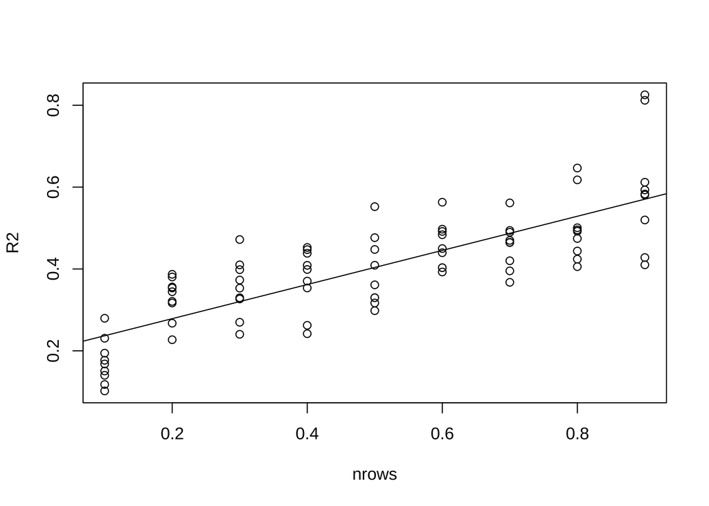

```r
plot(R2~nrows,data=hiperParametry)
model<-lm(R2~nrows,data = hiperParametry)$coe
abline(model)
```

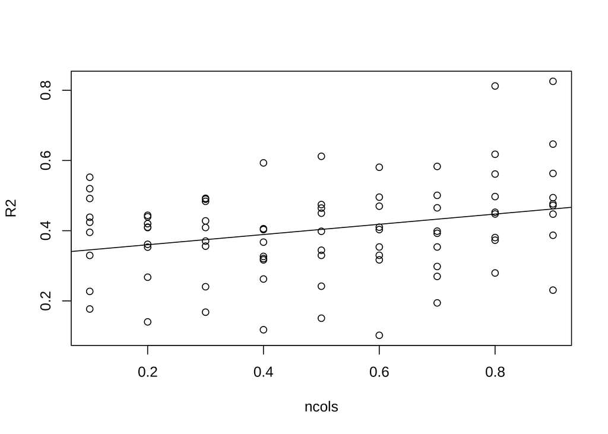

```r
plot(R2~ncols,data=hiperParametry)
model<-lm(R2~ncols,data = hiperParametry)$coe
abline(model)
```

# Odnalezienie lepszych modeli

Dla dwóch najlepiej dobranych hiperparametrow pod względem współczynnika determinancji sprawdzono modele przy większej liczbie drzew. Sprawdzono modele dla parametrów nrows=0.9, ncols=0.9 oraz nrows=0.9, ncols=0.8, przy liczbie drzew 100 i 200.

```r
parametryBaggingu<-dt_bagg(train, nrows=0.9, ncols=0.9, seedCols=43904, seedRows=43904, ileDrzew=100)
prognoza100_09_09<-sprawdzModel(parametryBaggingu, test)
```

```
 "rmse=2.572, R^2=0.692"
```

```r
parametryBaggingu<-dt_bagg(train, nrows=0.9, ncols=0.8, seedCols=43904, seedRows=43904, ileDrzew=100)
prognoza100_09_08<-sprawdzModel(parametryBaggingu, test)
```

```
 "rmse=2.516, R^2=0.614"
```

```r
parametryBaggingu<-dt_bagg(train, nrows=0.9, ncols=0.9, seedCols=43904, seedRows=43904, ileDrzew=200)
prognoza200_09_09<-sprawdzModel(parametryBaggingu, test)
```

```
 "rmse=2.56, R^2=0.67"
```

```r
parametryBaggingu<-dt_bagg(train, nrows=0.9, ncols=0.8, seedCols=43904, seedRows=43904, ileDrzew=200)
prognoza200_09_08<-sprawdzModel(parametryBaggingu, test)
```

```
 "rmse=2.519, R^2=0.621"
```

```r
ocena<-rbind(prognoza100_08_08,
prognoza200_07_05,
prognoza100_09_09,
prognoza100_09_08,
prognoza200_09_09,
prognoza200_09_08)
colnames(ocena)<-c("rmse","R2")
ocena<-as.data.frame(ocena)
ocena[order(ocena$R2, decreasing = TRUE),]
```

```
                      rmse        R2
prognoza100_09_09 2.572152 0.6921128
prognoza200_09_09 2.559631 0.6704187
prognoza200_09_08 2.518794 0.6206648
prognoza100_09_08 2.516153 0.6142793
prognoza100_08_08 2.476954 0.5714436
prognoza200_07_05 2.312592 0.3763489
```

# Wnioski

Proponuję się dobranie modelu o następujących (hiper)parametrach nrows=0.9 oraz ncols=0.9. Czyli wzięcie do budowy modelu 90% losowo wybranych wierszy oraz 90% losowo wybranych predyktorów.

# Uwagi końcowe

W zadaniu tym wykorzystano method=“anova”, która domyślnie jest wybierana przez bibliotekę rpart dla drzew regresyjnych. Ze względu na dyskretny, wykładniczy rozkład zmiennej y, w dalszych analizach można sprawdzić zbudowane drzewa metoda method=“class” lub method=“exp”. Można także spróbować przekształcić zmienna y oraz predyktory do postaci liniowej (zlinearyzować, np. obustronnie zlogarytmwać). Do trenowania modelu wybrano wszystkie obserwacje, które nie były użyte do testowania. Można także sprawdzić jak zachowa się model gdy podzieli się 60% i 40%, a następnie z 40% obserwacji wybierze 150.

# Prezentacja wyników

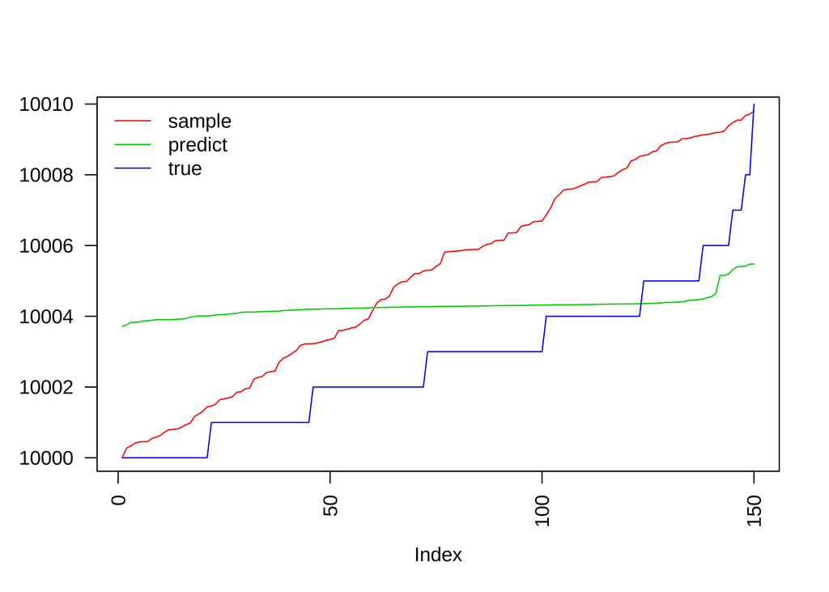

```r
seq<-seq(min(test$y),max(test$y),by=0.001)
sample<-sample(seq,length(test$y))
sample<-sample[order(sample)]
plot(sample, type="l",ylab="", col=2, las=2)
predict<-pobierzPrognoze(parametryBaggingu, test)
predict<-predict[order(predict)]
lines(predict,col=3,lty=1)
true<-test$y[order(test$y)]
lines(true,col=4,lty=1)
legend('topleft', c("sample","predict","true"), lty=c(1,1,1), col=c(2:4), bty='n',ncol=1)
```